# Project 2 Regression Set

Jane Shen

# Data Cleaning

Link to the data : https://www.kaggle.com/austinreese/craigslist-carstrucks-data

vehicle.csv is a dataset of vehicles listed on craigslist.

NA value counts(descending)

- county : 435,849
- size : 295,961
- condition : 186,806
- paint_color : 135,247
- drive : 122,011
- type : 117,108
- odometer : 75,148
- manufacturer : 20,747
- fuel : 2991
- transmission : 2146
- title_status : 1806
- year : 1117

These columns were removed because they are unnecessary :

- id, url, region_url, vin, description, image_url, long, lat

These columns were removed because they are almost entirely NA :

- county, size

These columns were removed because data is too variable and is oftentimes not representative of its actual purpose :

- model

(For example, sometimes the model value is “$500 DOWN PROGRAMS!!!” or “Honda-Nissan-Kia-Ford-Hyundai-VW”, because people on craigslist don’t use this feature for its intended purpose, so this data is not helpful)

```r
# Load data set
Vehicle <- read.csv("vehicles.csv", stringsAsFactors=TRUE, header=TRUE)
df <- Vehicle

# Remove unwanted columns
drop <- c("id","url","region_url","vin","description","image_url","long","lat","county","model", "size", "region")
df <- df[,!(names(df) %in% drop)]

# Convert empty strings to NA to make cleaning easier
library(dplyr)
df <- mutate_all(df, list(~na_if(.,"")))

# Keep only complete observations
df <- df[complete.cases(df),]

# Remove price values greater than $1,000,000 because there are only 6 cases, and they make graphing the data difficult
df <- df[df$price < 1000000,]

# Factor columns as needed
df$manufacturer <- as.factor(df$manufacturer)
df$condition <- as.factor(df$condition)
df$cylinders <- as.factor(df$cylinders)
df$fuel <- as.factor(df$fuel)
df$title_status <- as.factor(df$title_status)
df$transmission <- as.factor(df$transmission)
df$drive <- as.factor(df$drive)
df$type <- as.factor(df$type)
df$paint_color <- as.factor(df$paint_color)
df$state <- as.factor(df$state)
```

# Data Exploration

```r
summary(df)
```

```
     price             year         manufacturer       condition            cylinders           fuel
 Min.   :     0   Min.   :1900   ford     :23559            :    0   6 cylinders :44554           :     0
 1st Qu.:  4995   1st Qu.:2006   chevrolet:18487   excellent:60242   4 cylinders :40164   diesel  :  8598
 Median :  8999   Median :2011   toyota   :10917   fair     : 3224   8 cylinders :37502   electric:   139
 Mean   : 12021   Mean   :2010   nissan   : 7087   good     :44970   5 cylinders : 1175   gas     :113488
 3rd Qu.: 16400   3rd Qu.:2015   honda    : 7032   like new :15471   10 cylinders:  911   hybrid  :  1397
 Max.   :600000   Max.   :2021   jeep     : 5717   new      :  585   other       :  277   other   :  1163
                                 (Other)  :51986   salvage  :  293   (Other)     :  202
    odometer            title_status       transmission    drive              type        paint_color
 Min.   :       0             :     0            :     0      :    0   sedan    :32255   white  :30697
 1st Qu.:   60700   clean     :116396   automatic:111944   4wd:54292   SUV      :31557   black  :23573
 Median :  102730   lien      :  1551   manual   :  8637   fwd:43416   truck    :18969   silver :18931
 Mean   :  109418   missing   :   113   other    :  4204   rwd:27077   pickup   :13102   grey   :14957
 3rd Qu.:  145488   parts only:    30                                  coupe    : 7459   blue   :12712
 Max.   :10000000   rebuilt   :  4823                                  hatchback: 4917   red    :12433
                    salvage   :  1872                                  (Other)  :16526   (Other):11482
     state
 ca     :12298
 fl     : 8692
 ny     : 6267
 tx     : 6247
 wi     : 5524
 oh     : 4918
 (Other):80839
```

```r
dim(df)
```

```
[1] 124785     13
```

```r
names(df)
```

```
 [1] "price"        "year"         "manufacturer" "condition"    "cylinders"    "fuel"         "odometer"
 [8] "title_status" "transmission" "drive"        "type"         "paint_color"  "state"
```

```r
str(df)
```

```
'data.frame':   124785 obs. of  13 variables:
 $ price       : num  9000 8500 2750 24930 3200 ...
 $ year        : int  2004 2005 2006 2017 1998 2000 2008 2013 2010 2012 ...
 $ manufacturer: Factor w/ 43 levels "","acura","alfa-romeo",..: 9 15 9 39 42 22 12 33 41 2 ...
 $ condition   : Factor w/ 7 levels "","excellent",..: 2 2 4 2 4 4 4 2 2 4 ...
 $ cylinders   : Factor w/ 9 levels "","10 cylinders",..: 6 7 8 5 5 7 7 5 8 7 ...
 $ fuel        : Factor w/ 6 levels "","diesel","electric",..: 4 4 4 4 4 4 4 4 4 4 ...
 $ odometer    : int  54000 62800 165000 32989 98186 198200 144497 45500 168896 132867 ...
 $ title_status: Factor w/ 7 levels "","clean","lien",..: 2 2 2 2 2 2 2 2 2 2 ...
 $ transmission: Factor w/ 4 levels "","automatic",..: 2 2 2 2 3 2 2 2 2 2 ...
 $ drive       : Factor w/ 4 levels "","4wd","fwd",..: 4 4 2 2 4 2 3 2 2 2 ...
 $ type        : Factor w/ 14 levels "","bus","convertible",..: 9 3 12 11 4 11 6 11 11 11 ...
 $ paint_color : Factor w/ 13 levels "","black","blue",..: 10 11 12 7 3 6 3 11 7 2 ...
 $ state       : Factor w/ 51 levels "ak","al","ar",..: 4 22 22 27 27 27 38 27 38 38 ...
```

```r
head(df)
```

|  | price | year | manufacturer | condition | cylinders | fuel | odometer | title_status | transmission | drive | type | paint_color | state |
| --- | --- | --- | --- | --- | --- | --- | --- | --- | --- | --- | --- | --- | --- |
| 4 | 9000 | 2004 | chevrolet | excellent | 5 cylinders | gas | 54000 | clean | automatic | rwd | pickup | red | az |
| 8 | 8500 | 2005 | ford | excellent | 6 cylinders | gas | 62800 | clean | automatic | rwd | convertible | silver | me |
| 13 | 2750 | 2006 | chevrolet | good | 8 cylinders | gas | 165000 | clean | automatic | 4wd | truck | white | me |
| 20 | 24930 | 2017 | subaru | excellent | 4 cylinders | gas | 32989 | clean | automatic | 4wd | SUV | grey | mt |
| 27 | 3200 | 1998 | volkswagen | good | 4 cylinders | gas | 98186 | clean | manual | rwd | coupe | blue | mt |
| 30 | 3450 | 2000 | jeep | good | 6 cylinders | gas | 198200 | clean | automatic | 4wd | SUV | green | mt |

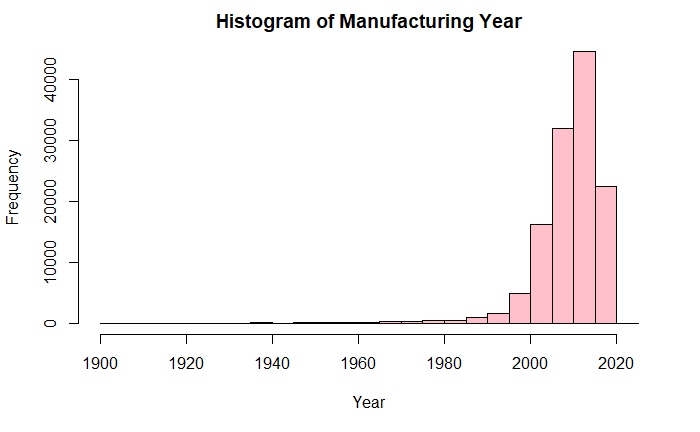

```r
hist(df$year, col="pink", main="Histogram of Manufacturing Year", xlab="Year")
```

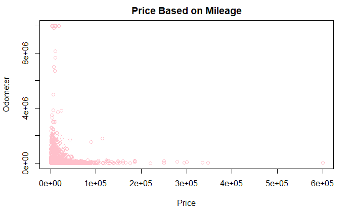

```r
plot(df$price, df$odometer, xlab="Price", ylab="Odometer", main="Price Based on Mileage", col="pink", pch=1)
```

# Modeling

```r
library(caret)
library(class)
library(e1071)

# Remove manufacturer morgan because there is only one instance, and it can not show up in both train and test.
df <- df[!df$manufacturer=="morgan",]

# Divide into train and test sets
set.seed(1234)
i <- sample(1:nrow(df), nrow(df) * 0.75, replace=FALSE)
train <- df[i,]
test <- df[-i,]
```

# Linear Regression

```r
# Build the model
lm1 <- lm(price~., data=train)
summary(lm1)
```

```
Call:
lm(formula = price ~ ., data = train)

Residuals:
   Min     1Q Median     3Q    Max
-58648  -3910   -765   2669 579449

Coefficients:
                              Estimate Std. Error t value Pr(>|t|)
(Intercept)                 -7.377e+05  8.463e+03 -87.169  < 2e-16 ***
year                         3.819e+02  4.190e+00  91.141  < 2e-16 ***
manufactureralfa-romeo       9.119e+03  2.050e+03   4.448 8.68e-06 ***
manufactureraston-martin     4.083e+04  3.653e+03  11.175  < 2e-16 ***
manufactureraudi             9.393e+02  3.927e+02   2.392 0.016767 *
manufacturerbmw             -8.314e+02  3.424e+02  -2.428 0.015186 *
manufacturerbuick            5.902e+02  3.920e+02   1.505 0.132229
manufacturercadillac         6.221e+02  3.771e+02   1.650 0.098983 .
manufacturerchevrolet       -1.557e+02  3.098e+02  -0.503 0.615163
manufacturerchrysler        -1.609e+03  3.687e+02  -4.362 1.29e-05 ***
manufacturerdatsun           1.269e+04  2.340e+03   5.423 5.88e-08 ***
manufacturerdodge           -1.113e+03  3.357e+02  -3.314 0.000921 ***
manufacturerferrari          6.421e+04  2.266e+03  28.341  < 2e-16 ***
manufacturerfiat            -3.509e+03  6.925e+02  -5.067 4.05e-07 ***
manufacturerford            -4.066e+02  3.085e+02  -1.318 0.187506
manufacturergmc              9.282e+02  3.304e+02   2.809 0.004965 **
manufacturerharley-davidson  2.537e+03  1.638e+03   1.549 0.121416
manufacturerhonda            6.563e+01  3.207e+02   0.205 0.837860
manufacturerhyundai         -1.086e+03  3.468e+02  -3.132 0.001739 **
manufacturerinfiniti         2.061e+02  4.085e+02   0.505 0.613858
manufacturerjaguar           2.529e+02  5.890e+02   0.429 0.667642
manufacturerjeep             7.614e+02  3.279e+02   2.322 0.020234 *
manufacturerkia             -1.339e+03  3.663e+02  -3.657 0.000256 ***
manufacturerland rover       7.111e+02  2.969e+03   0.240 0.810678
manufacturerlexus            1.604e+03  3.780e+02   4.244 2.20e-05 ***
manufacturerlincoln         -1.218e+03  4.499e+02  -2.708 0.006762 **
manufacturermazda           -1.237e+03  3.892e+02  -3.179 0.001478 **
manufacturermercedes-benz    1.233e+03  3.504e+02   3.520 0.000431 ***
manufacturermercury         -3.080e+03  5.341e+02  -5.767 8.10e-09 ***
manufacturermini            -1.384e+03  5.177e+02  -2.674 0.007493 **
manufacturermitsubishi      -1.715e+03  4.638e+02  -3.697 0.000218 ***
```

[output cut: 101 more lines]

```
statetn                     -1.439e+03  3.623e+02  -3.972 7.13e-05 ***
statetx                     -2.573e+03  3.418e+02  -7.528 5.19e-14 ***
stateut                     -1.620e+03  5.757e+02  -2.814 0.004895 **
stateva                     -2.989e+03  3.607e+02  -8.287  < 2e-16 ***
statevt                     -1.023e+03  4.165e+02  -2.456 0.014033 *
statewa                     -1.434e+03  4.021e+02  -3.566 0.000363 ***
statewi                     -1.123e+03  3.438e+02  -3.265 0.001095 **
statewv                      7.222e+01  7.530e+02   0.096 0.923598
statewy                     -6.083e+02  7.407e+02  -0.821 0.411530
---
Signif. codes:  0 ‘***’ 0.001 ‘**’ 0.01 ‘*’ 0.05 ‘.’ 0.1 ‘ ’ 1

Residual standard error: 8349 on 93447 degrees of freedom
Multiple R-squared:  0.3732,    Adjusted R-squared:  0.3722
F-statistic: 397.3 on 140 and 93447 DF,  p-value: < 2.2e-16
```

```r
# Evaluate on test data
pred_lm <- predict(lm1, newdata=test)
cor_lm <- cor(pred_lm, test$price)
mse_lm <- mean((pred_lm - test$price)^2)

print(paste("correlation: ", cor_lm))
```

```
[1] "correlation:  0.615964542687117"
```

```r
print(paste("mse: ", mse_lm))
```

```
[1] "mse:  67041812.8068297"
```

# Decision Tree

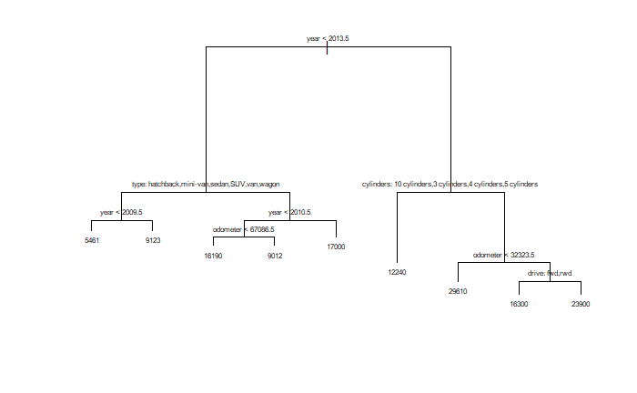

```r
# Build the model
library(tree)
tree1 <- tree(train$price~.-state-manufacturer, data=train)
plot(tree1)
text(tree1, cex=0.5, pretty=0)
```

```r
# Evaluate on test data
pred_tree <- predict(tree1, newdata=test)
cor_tree <- cor(pred_tree, test$price)
mse_tree <- mean((pred_tree - test$price)^2)

print(paste("correlation: ", cor_tree))
```

```
[1] "correlation:  0.632056872993675"
```

```r
print(paste("mse: ", mse_tree))
```

```
[1] "mse:  64876447.7624198"
```

# Radial SVM

```r
# Build the model
svm1 <- svm(price~., data=train[1:4254,], kernel="radial", cost=100)
summary(svm1)
```

```
Call:
svm(formula = price ~ ., data = train[1:4254, ], kernel = "radial", cost = 100)


Parameters:
   SVM-Type:  eps-regression
 SVM-Kernel:  radial
       cost:  100
      gamma:  0.006622517
    epsilon:  0.1


Number of Support Vectors:  2649
```

```r
# Evaluate on training set
pred_svm = predict(svm1, newdata=test[1:709,])
cor_svm = cor(pred_svm, test$price[1:709])
mse_svm = mean((pred_svm - test$price)^2)

print(paste("correlation: ", cor_svm))
```

```
[1] "correlation:  0.681522523901837"
```

```r
print(paste("mse: ", mse_svm))
```

```
[1] "mse:  172542200.190433"
```

# Ensemble Method

The ensemble method XGBoost did better than all other models at a correlation of 0.82582, while all others were lower than 0.7. It also achieved the lowest MSE. Feature selection for XGBoost remains the same as for other models to get a better comparison between algorithsm.

```r
# Build the model
library(xgboost)
bst1 <- xgboost(data=data.matrix(train[,-1], rownames.force=NA), label=data.matrix(train[,1], rownames.force=NA), nround=100, objective="reg:tweedie")
summary(bst1)
```

```
               Length Class              Mode
handle              1 xgb.Booster.handle externalptr
raw            395896 -none-             raw
niter               1 -none-             numeric
evaluation_log      2 data.table         list
call               14 -none-             call
params              2 -none-             list
callbacks           2 -none-             list
feature_names      12 -none-             character
nfeatures           1 -none-             numeric
```

```r
# Evaluate on test set
pred_bst <- predict(bst1, data.matrix(test[,-1], rownames.force=NA))
cor_bst <- cor(pred_bst, data.matrix(test$price, rownames.force=NA))
mse_bst <- mean((pred_bst - test$price)^2)

print(paste("correlation: ", cor_bst))
```

```
[1] "correlation:  0.825818596144421"
```

```r
print(paste("mse: ", mse_bst))
```

```
[1] "mse:  34370348.3787109"
```

# Comparison and Analysis

Best to worst correlation vs MSE

- XGBoost : 0.82582 vs 34,370,348
- Radial SVM : 0.68152 vs 172,542,200
- Decision Tree : 0.63206 vs 64,876,448
- Linear Regression : 0.61596 vs 67,041,813

Unsurprisingly, XGBoost won in both highest correlation and lowest MSE by a landslide. This is expected because XGBoost is known to be better than other models in both accuracy, speed, and interpretability.

Radial SVM had the best correlation of non-ensemble models but largest MSE, while linear regression had the worst correlation and a lower MSE. We can conclude that linear regression has the worst correlation probably because it assumes a linear data set, but as we can tell from the graph, it is obviously quite curved. For this same reason, the Radial SVM worked the best - as it’s a good approach when the data is not linearly separable.

From the results of the data, as expected, cars that are older, have a higher odometer value, and worse condition are sold for much cheaper than those that are the opposite. The value with the biggest influence on the price seems to be the car model’s age, and from the tree, we can see that for older cars, sellers prioritize the car type - namely whether it is a “family” car(mini-van, suv, etc) or a “personal” car. For newer cars, sellers prioritize cylinder count and odometer value in naming price.